# Reproducibility

Reproducibility is crucial to ensuring the validity of our results. This is a pressing issue in science today because a non-trivial number of publications can’t be validated by follow up studies. Nature has a series of articles about this phenomenon, how various disciplines feel, and how to best counter the “Replicability crisis”. More reading here: https://www.nature.com/news/1-500-scientists-lift-the-lid-on-reproducibility-1.19970?WT.mc_id=SFB_NNEWS_1508_RHBox

Today we’ll cover ways that we can measure aspects of reproducibility both within an individual project and between projects that ask the same question.

We’ll start with the simple stuff and work our way up to partitioning variance once again.

### Comparing variances

The coefficient of variation is an important measure of dispersion when you are comparing measurements that come from different scales. While not always the case, variance tends to increase as the mean increases. So, one way of dealing with that bias in measuring variation is to standardize our estimates of dispersion by the mean:

$$CV=\frac{\sigma}{\mu}$$
Consider the following example (modified from https://www.r-bloggers.com/measure-of-relative-variability/):

```r
heights <- c(151, 160, 162, 155, 154, 168, 153, 158, 157, 150, 167)
weights <- c(61, 69, 73, 65, 64, 78, 63, 68, 67, 60, 77)
paste0("Variance in height: ", round(var(heights), digits = 2))
```

```
[1] "Variance in height: 36.42"
```

```r
paste0("Variance in weight: ", round(var(weights), digits = 2))
```

```
[1] "Variance in weight: 37.02"
```

The variances are basically the same, but the scales are different. By standardizing with the mean, we can see that weight is more variable than height.

```r
#CV
paste0("CV heights: ", round(sd(heights)/mean(heights) * 100, digits = 2))
```

```
[1] "CV heights: 3.83"
```

```r
paste0("CV weights: ", round(sd(weights)/mean(weights) * 100, digits = 2))
```

```
[1] "CV weights: 8.98"
```

CV is a really simple way of standardizing variances for comparison, just take note that it’s not stable with mean values that are close to zero:

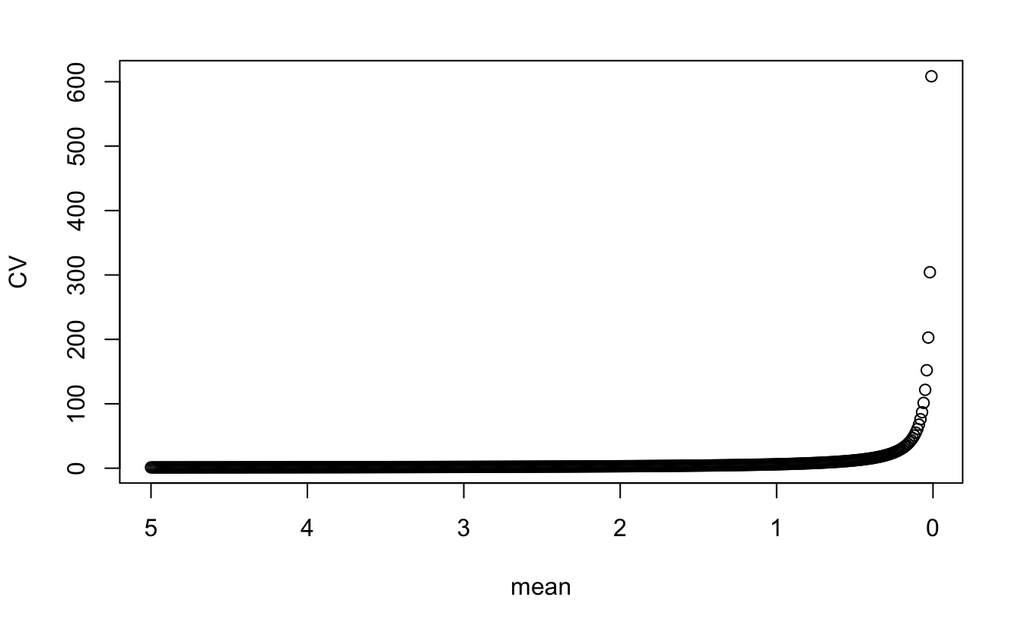

### CV(RMSD)

The root mean square deviation is a measure of accuracy in the predictions of a regression model:

$$\sqrt {\frac {\sum\limits_{i = 1}^{n} (\hat y_i - y_i)^2}{n}}$$

RMSD is also generally scale dependent and can be measured relative to the mean to be standardized.

$$CV(RMSD) = \frac {RMSD}{\bar y}$$

Here’s a simulated regression model that we can use to measure RMSD and CV(RMSD):

```r
x1 <- seq(4, 12, .2)
#here's the "true model" with some noise added
b0 <- 100
b1 <- 15
y.res <- rnorm(x1, mean = 0, sd = 5)
y <- b0 + b1 * x1
plot(y ~ x1, typ = "l", main = "Visualizing residuals", ylim = range(y.res + y))
points(y.res + y ~ x1)
```

```r
segments(x1, y, x1, y.res + y, col = "red")
text(x = 4.5, y = 265, labels = paste0("RMSD: ", round(sqrt(sum(((y.res + y) - y)^2) / length(x1)), digits = 2)))
```

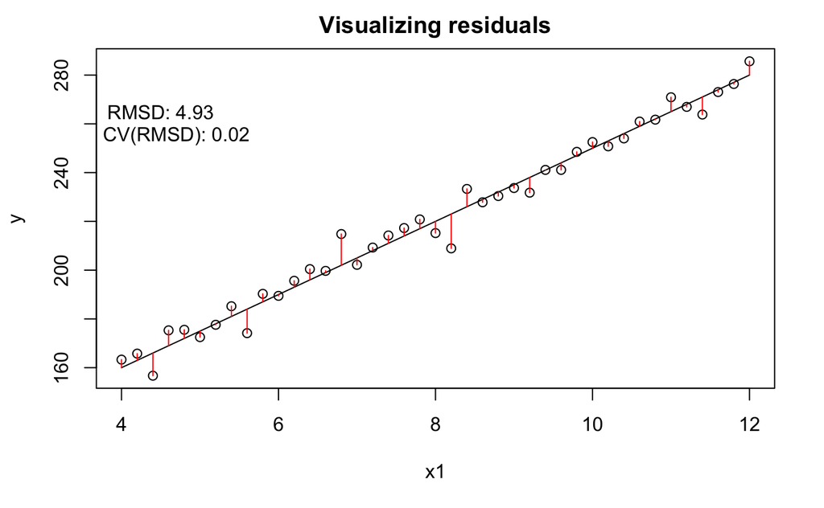

```r
text(x = 4.7, y = 255, labels = paste0("CV(RMSD): ", round(sqrt(sum(((y.res + y) - y)^2) / length(x1))/mean(y.res + y), digits = 2)))
```

### Bootstrapping

Above we simulated a model by taking the true parameters and adding noise to produce residuals. In practice, we estimate the parameters $b_0$ and $b_1$ and all of our collected data gives us one estimate of the slope of the relationship between our independent and dependent variables. If we want to measure how reproducible our estimates are, we can sample our data repeatedly, keeping the sample size constant but repeating measurements randomly.

```r
n.resamples <- 1000
rep.estimates <- rep(NA, n.resamples)
for(i in 1:n.resamples){
  sample.index <- runif(n = length(x), min = 1, max = length(x))
  rep.estimates[i] <- lm((y.res + y)[sample.index] ~ x1[sample.index])$coef[2]
}
hist(rep.estimates, xlab = "Parameter estimate")
abline(v = b1, lwd = 2, col = "red")
```

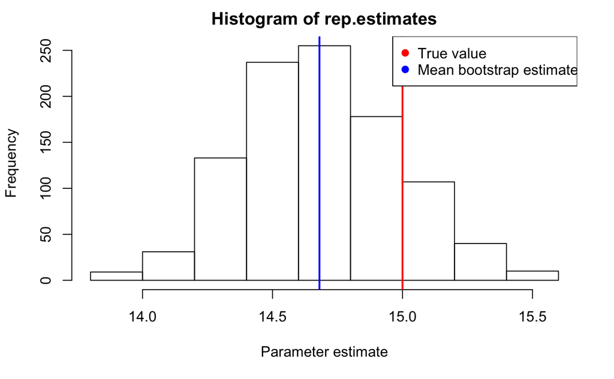

```r
abline(v = mean(rep.estimates), lwd = 2, col = "blue")
legend("topright", pch = 19, col = c("red", "blue"), legend = c("True value", "Mean bootstrap estimate"))
```